# Math 421 - Midterm

## Instruction

The midterm has two components: the Rmarkdown notebook (html) and the presentation. We will do the presentation in class. Post both the notebook and the presentation on your Github page.

**The notebook:** The notebook should be created using `rmarkdown` or Quarto (like other assignments). The notebook should have a title.

**The Presentation:** Present your results in 5-10 minutes. To make the presentation using Rmarkdown, do the follows:

```
- In Rstudio -> File -> New File -> R markdown

- In the left panel, click to Presentation -> Click OK

- Now you have an Rmarkdown that can be knitted to be a html presentation
```

- You can also use the Rmd templates of the class slides.
- You can also use Quarto to create the presentation: *In Rstudio -> File -> New File -> Quarto Presentation…*
- You do not need to rerun all the codes for the presentation. For example, to show the model comparison, you just need to show the image of the model comparison instead of running all the models again.
- To inset an image in a slide, use `![](image.png)`
- To scale images, you can use `![](image.png){width="60%"}` or follow these below instructions.
  - https://bookdown.org/yihui/rmarkdown-cookbook/figure-size.html
  - http://zevross.com/blog/2017/06/19/tips-and-tricks-for-working-with-images-and-figures-in-r-markdown-documents/
- To turn off message and warning of a code cell, use: `{r, message=FALSE, warning=FALSE}` for the cell.

**What to present**:

- Present Part 2 - Visualization
- Present Question Question 4, 5 and 6 in Part 3.
- Present any errors/challenges you run into and how you fix/overcome them.

**Data:**

The data for the mid-term project is the Rhode Island Department of Health Hospital Discharge Data. Each row of the data presents a patient.

Link: https://drive.google.com/open?id=15QNBf6YYKocK2nNIfpKDer58kQnCPNZJ

**Notice**

- Since this is a large dataset, you could try to run the codes on the smaller dataset, which is a portion of the original dataset before running the codes on the original data. To create a random subset of the data you could use

# find the number of rows of the data

n = nrow(df)

# subset 1000 rows of the data

df1 = df[sample(1:n, 1000), ]

## I. Data Wranggling

1. Download the data file `hdd0318cy.sas7bdat`.
2. Use `read_sas` in library `haven` to read the data.

```r
library(haven)
library(tidyverse)
library(dplyr)
#df = read_sas('hdd0318cy.sas7bdat')
df = read_csv('MaseraEmilyMidterm.csv')
```

3. Filter the data to have only patients of the year 2018 (`yod=18`)

```r
df1 = df %>% filter(yod == 18)
```

4. Select to work with only following variables:

   ```
                  "yod", "payfix","pay_ub92","age",
                  "sex","raceethn","provider","moa",
                  "yoa","mod","admtype", "asource" ,
                  "preopday" ,"los", "service" , "icu","ccu",
                  "dispub92", "payer"  ,"drg","trandb",
                  "randbg","randbs","orr", "anes","seq",
                  "lab","dtest", "ther","blood","phar",
                  "other","patcon","bwght","total","tot" ,
                  "ecodub92","b_wt","pt_state","diag_adm","ancilar" ,
                  "campus","er_fee","er_chrg","er_mode","obs_chrg",
                  "obs_hour","psycchrg","nicu_day"
   ```

```r
df = df1 %>% select("yod", "payfix","pay_ub92","age",
                      "sex","raceethn","provider","moa",
                      "yoa","mod","admtype", "asource" ,
                      "preopday" ,"los", "service" , "icu","ccu",
                      "dispub92", "payer"  ,"drg","trandb",
                      "randbg","randbs","orr", "anes","seq",
                      "lab","dtest", "ther","blood","phar",
                      "other","patcon","bwght","total","tot" ,
                      "ecodub92","b_wt","pt_state","diag_adm","ancilar" ,
                      "campus","er_fee","er_chrg","er_mode","obs_chrg",
                      "obs_hour","psycchrg","nicu_day")
```

*Notice*: You may want to save the current data to your computer for easy access later. To save the data file use `write_csv(df, 'midterm.csv')`, for example.

```r
write_csv(df1, 'MaseraEmilyMidterm.csv' )
```

5. What are variables that have missing values?

```r
colSums(is.na(df1))
```

```
##      yod   payfix pay_ub92      age      sex raceethn  filler1  filler2
##        0   131478        0        0        0     3950   131478   131478
## provider      moa      yoa      mod  admtype  asource  filler3      dx1
##        0        0        0        0        1        6   131478        6
##      dx2      dx3      dx4      dx5      dx6      dx7      px1      px2
##      658     2995     9046    17097    25109    32911    60486    80619
##      px3      px4      px5      px6      px7      px8      px9     px10
##    96835   109573   115511   121065   122544   125272   125741   127292
## preopday      los  filler4  service      icu      ccu dispub92    payer
##    60486        0   131478        0        0        0        0        0
##      drg   trandb   randbg   randbs      orr     anes      seq      lab
##        0        0        0        0        0        0        0        0
##    dtest     ther    blood     phar    other   patcon    bwght  filler6
##        0        0        0        0        0        0   131478   131478
##    total      tot      dx8      dx9     dx10     dx11 ecodub92     b_wt
##        0        0    40355    47624    54443    61199   104339        0
## pt_state diag_adm  ancilar   campus   er_fee  er_chrg  er_mode obs_chrg
##        3       50        0        0        0        0    12158        0
## obs_hour psycchrg nicu_day     dx12     dx13     dx14     dx15     dx16
##    77343        0   124090    67304    73152    78808    84159    89328
##     dx17     dx18     dx19     dx20     dx21     dx22     dx23     dx24
##    94019    98425   102439   106035   109344   112219   114834   117112
##     dx25     px11     px12     px13     px14     px15     px16     px17
##   119097   127497   128547   128640   129299   129342   129853   129880
##     px18     px19     px20     px21     px22     px23     px24     px25
##   130233   130265   130522   130538   130725   130729   130877   130890
##  filler7     race   ethnic     poa1     poa2     poa3     poa4     poa5
##   131478        9        0     6451     7699    12409    19531    26665
##     poa6     poa7     poa8     poa9    poa10    poa11    poa12    poa13
##    33952    41006    47899    54545    61049    67129    72909    78316
##    poa14    poa15    poa16    poa17    poa18    poa19    poa20    poa21
##    83713    88534    93259    97499   101637   105171   108438   111493
##    poa22    poa23    poa24    poa25 ecodepoa  filler8 filler6a
##   113923   116403   118453   120268   131478        0   131478
```

6. Remove all variables with missing values.

```r
df = df %>% select(-payfix, -raceethn, -admtype, -asource, -preopday, -bwght, -ecodub92, -pt_state, -diag_adm, -er_mode, -obs_hour, -nicu_day)
```

7. Refer to the data description in the file `HDD2015-18cy6-20-19.docx`, which variable recording the month of admission?, which variable recording the month of discharge?

##The variable for month of admission is moa and the variable for month of discharge is mod##

8. Which month admitted the most number of patients? Which month admitted the most number of male patients?

```r
df %>% count(moa) %>% arrange(-n)
```

```
## # A tibble: 12 × 2
##      moa     n
##    <dbl> <int>
##  1    10 11408
##  2     5 11404
##  3     1 11309
##  4     8 11199
##  5     4 11174
##  6     3 11073
##  7     7 10962
##  8    12 10698
##  9     6 10690
## 10     9 10666
## 11    11 10636
## 12     2 10259
```

```r
##October admitted the most number of patients##
df %>% filter(sex=='1') %>% count(moa) %>% arrange(-n)
```

```
## # A tibble: 12 × 2
##      moa     n
##    <dbl> <int>
##  1    10  5164
##  2     5  5066
##  3     8  5028
##  4     4  4989
##  5     3  4978
##  6     1  4970
##  7     7  4910
##  8    12  4855
##  9     6  4810
## 10    11  4800
## 11     9  4683
## 12     2  4546
```

```r
##October also admitted the most male patients##
```

9. Which month has the most number of teenage female patients?

```r
df %>% filter(sex=='2', age>='13'& age<='19') %>%
  count(moa) %>% arrange(-n)
```

```
## # A tibble: 12 × 2
##      moa     n
##    <dbl> <int>
##  1     3   226
##  2     5   220
##  3    10   212
##  4    12   208
##  5     1   207
##  6     9   196
##  7     4   187
##  8    11   177
##  9     2   172
## 10     8   172
## 11     7   171
## 12     6   169
```

```r
## March has the most number of teenage female patients##
```

10. Which provider has the most number of female patients in October?

```r
df %>% filter(sex=='2', moa=='10') %>% count(provider) %>% arrange(-n)
```

```
## # A tibble: 12 × 2
##    provider     n
##       <dbl> <int>
##  1     7205  1517
##  2     7214  1224
##  3     7204   872
##  4     7210   699
##  5     7209   351
##  6     7206   333
##  7     7213   317
##  8     7201   294
##  9     7216   256
## 10     7202   212
## 11     7211   122
## 12     7215    46
```

```r
##provider 7205 has the most number of female patietns in October
```

11. Are female patients older than male patients, on average?

```r
df %>% group_by(sex) %>% summarise(average_age = mean(age)) %>% arrange(-average_age)
```

```
## # A tibble: 3 × 2
##     sex average_age
##   <dbl>       <dbl>
## 1     1        51.5
## 2     2        50.9
## 3     9        43
```

```r
##Male patients are older on average##
```

12. Calculate the average age of patients by months. Which month has the oldest patients on average age?

```r
df %>% group_by(moa) %>% summarise(average_age = mean(age)) %>% arrange(-average_age)
```

```
## # A tibble: 12 × 2
##      moa average_age
##    <dbl>       <dbl>
##  1     1        51.8
##  2     6        51.5
##  3    12        51.5
##  4     4        51.4
##  5     7        51.3
##  6     2        51.2
##  7     3        51.1
##  8    11        51.0
##  9     8        50.9
## 10    10        50.8
## 11     5        50.6
## 12     9        50.6
```

```r
##January has the oldest average age##
```

13. What is the name of the provider that has the highest total charge?

```r
df %>% group_by(provider) %>% summarise(average_tot = mean(tot)) %>% arrange(-average_tot)
```

```
## # A tibble: 12 × 2
##    provider average_tot
##       <dbl>       <dbl>
##  1     7215      69946.
##  2     7205      48739.
##  3     7213      38200.
##  4     7202      35504.
##  5     7204      35277.
##  6     7206      31018.
##  7     7210      27691.
##  8     7209      24539.
##  9     7211      24089.
## 10     7201      22775.
## 11     7214      22362.
## 12     7216      17782.
```

```r
##Provider 7215 has the highest total charge##
```

14. What is the name of the provider that has the least total charge for teenage male on average?

```r
df %>% group_by(provider) %>% filter(sex=='1', age>='13'& age<='19') %>% summarise(average_tot = mean(tot)) %>% arrange(average_tot)
```

```
## # A tibble: 12 × 2
##    provider average_tot
##       <dbl>       <dbl>
##  1     7206      10360.
##  2     7201      14434.
##  3     7210      18586.
##  4     7211      19742.
##  5     7213      22618.
##  6     7216      24060.
##  7     7204      24989.
##  8     7209      26573.
##  9     7214      28950
## 10     7202      29389.
## 11     7205      40215.
## 12     7215     100440.
```

```r
##provider 7206 has the least total charge for teenage male on average##
```

15. Create a season (Spring, Summer, Fall, Winter) variable. Calculate the length of stays by season. Which season has the longest length of stays on average?

```r
df$season <- case_when(df$moa >=3 & df$moa < 6 ~ 'Spring', df$moa >= 6 & df$moa < 9 ~'Summer', df$moa >=9 & df$moa <12 ~ 'Fall', TRUE ~ 'Winter')
df %>% group_by(season) %>% summarise(average_los = mean(los)) %>% arrange(-average_los)
```

```
## # A tibble: 4 × 2
##   season average_los
##   <chr>        <dbl>
## 1 Summer        4.96
## 2 Fall          4.96
## 3 Winter        4.93
## 4 Spring        4.84
```

```r
##Summer has the longest length of stay on average##
```

16. On average, how much a 20 year-old male get charged for staying 1 day in the Fall season?

```r
df %>%
  filter(sex=='1', age=='20', season=='Fall', los=='1') %>%
  summarise(average_tot = mean(tot)) %>%
  arrange(average_tot)
```

```
## # A tibble: 1 × 1
##   average_tot
##         <dbl>
## 1       16511
```

```r
##On average, a 20 year old male gets charged $16,511 for staying 1 day in the fall season##
```

17. Write a paragraph to summarize the section and give your comments on the results. You could do some other calculations to support your points.

## II. Data Visualization

Continue with the data from part I.

1. Provides at least 10 meaningful plots. Comments on the plots. All plots should have title, caption, appropriate labels on x and y-axis

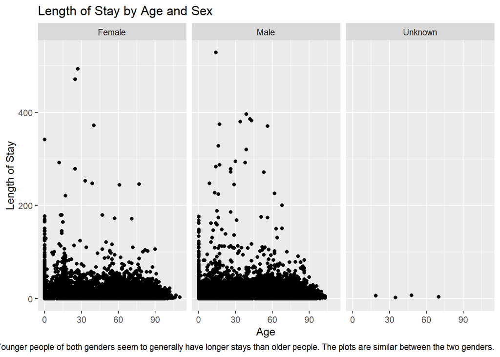

```r
library(ggplot2)
library(dplyr)
df$sex = case_when(df$sex == 1 ~ 'Male',
                   df$sex == 2 ~ 'Female',
                   TRUE ~ 'Unknown')

df %>% ggplot() + geom_point(mapping=aes(x=age, y=los)) + facet_wrap(~sex) +
  labs(x='Age',
       y = 'Length of Stay',
       title = 'Length of Stay by Age and Sex',
       caption = 'Younger people of both genders seem to generally have longer stays than older people. The plots are similar between the two genders.')
```

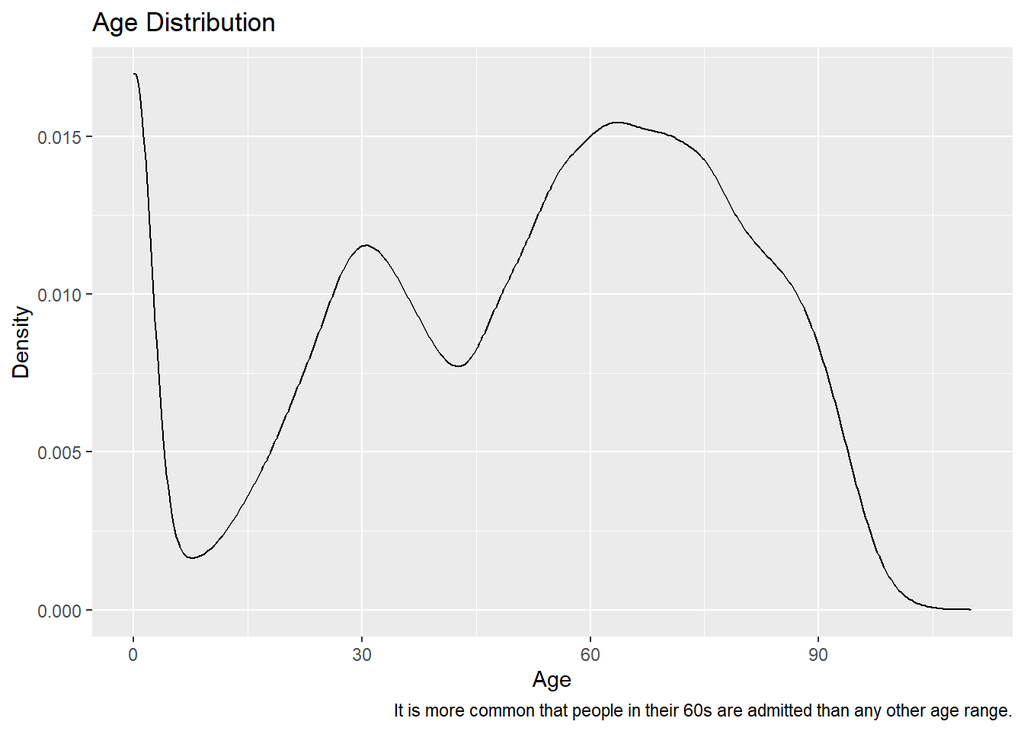

```r
df %>% ggplot()+
  geom_density(mapping = aes(x = age)) +
  labs(x="Age", y="Density", title = "Age Distribution", caption='It is more common that people in their 60s are admitted than any other age range.')
```

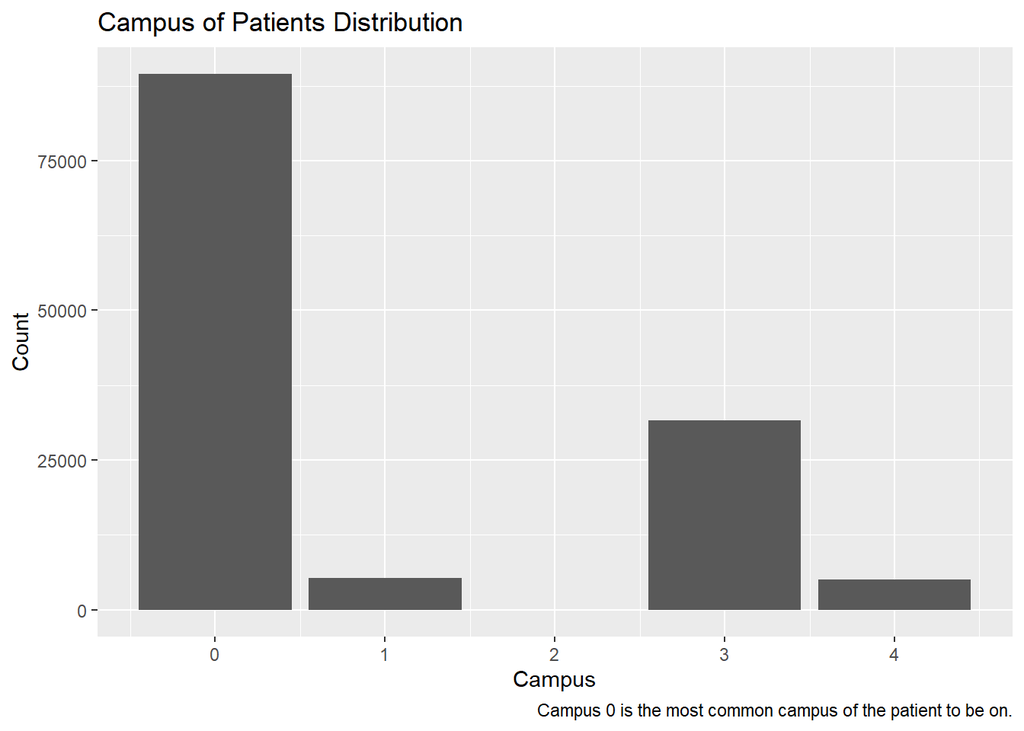

```r
df %>% ggplot()+
  geom_bar(mapping = aes(x = campus))+
  labs(x="Campus", y="Count", title = "Campus of Patients Distribution", caption='Campus 0 is the most common campus of the patient to be on.')
```

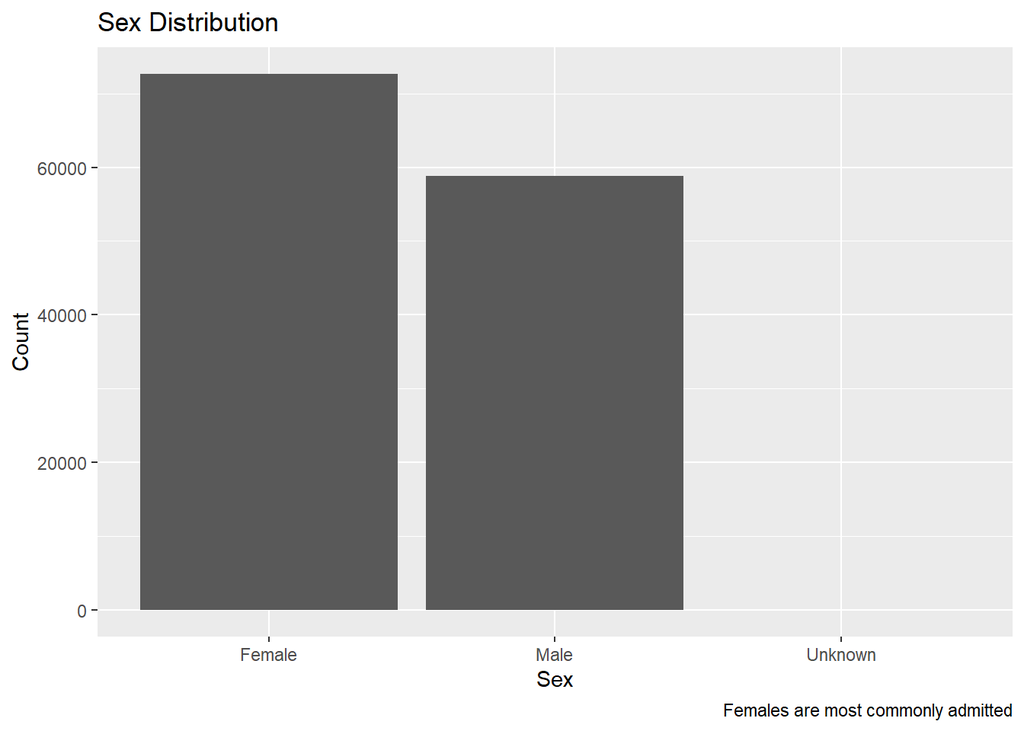

```r
df %>% ggplot()+
  geom_bar(mapping = aes(x = sex))+
  labs(x="Sex", y="Count", title = "Sex Distribution", caption="Females are most commonly admitted")
```

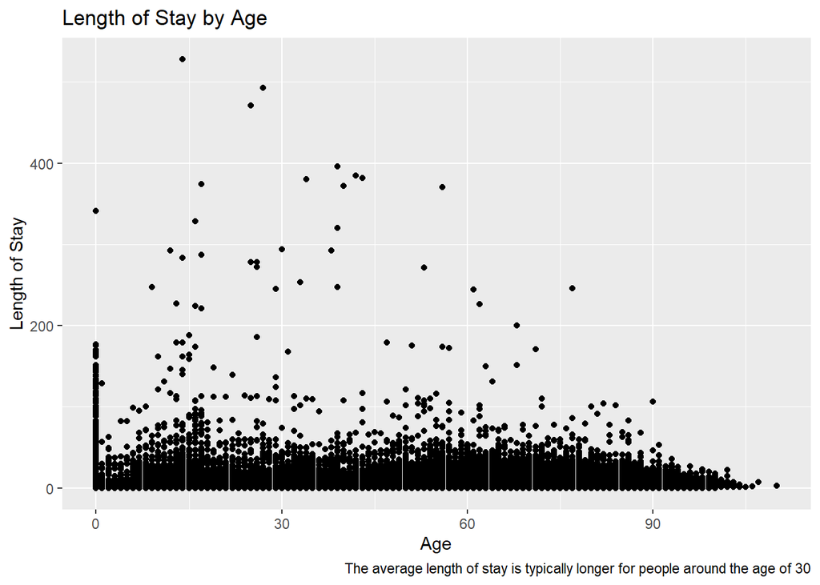

```r
df %>% ggplot()+geom_point(aes(x=age, y=los))+
  labs(x="Age", y="Length of Stay", title = "Length of Stay by Age", caption="The average length of stay is typically longer for people around the age of 30")
```

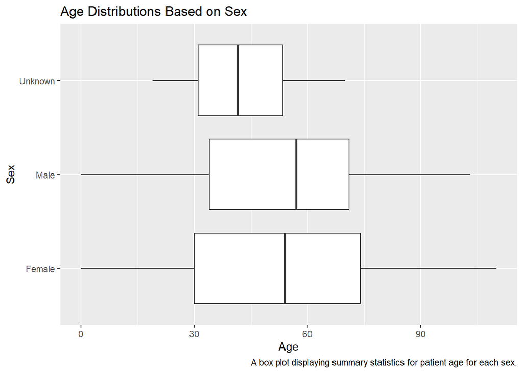

```r
df %>%
  ggplot()+
  geom_boxplot(mapping = aes(x = age, y = sex))+
  labs(x='Age',
       y='Sex',
       title='Age Distributions Based on Sex',
       caption='A box plot displaying summary statistics for patient age for each sex.')
```

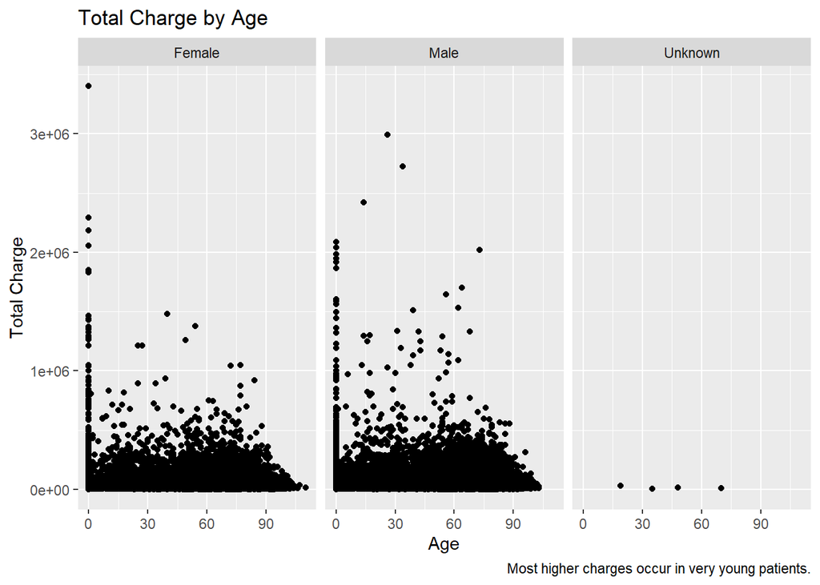

```r
df %>% ggplot() + geom_point(mapping=aes(x=age, y=tot)) + facet_wrap(~sex) +
  labs(x='Age',
       y = 'Total Charge',
       title = 'Total Charge by Age',
       caption = 'Most higher charges occur in very young patients.')
```

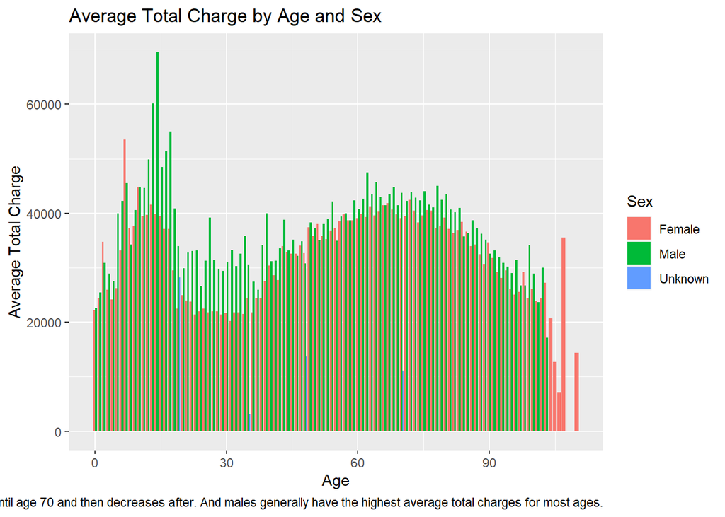

```r
df %>% group_by(sex,age) %>%
  summarise(mean_charge = mean(tot)) %>% ggplot() +
  geom_col(aes(x=age, y=mean_charge, fill=sex), position = 'dodge') +
  labs(x='Age',
       y='Average Total Charge',
       fill = 'Sex',
       title = 'Average Total Charge by Age and Sex',
       caption = 'There is a peak in average change at the age of 15, especially for males. The average total charge generally increases until age 70 and then decreases after. And males generally have the highest average total charges for most ages.')
```